# Fire Data

This notebook aims to take a holistic approach to examining US fires from 1992-2015 to see if any trends and patterns are visible. We will do this by examining the various causes of fires, locations of fires, density of fires in said locations, and the differences of fire seasons year-by-year in the US.

Data Source: https://www.fs.usda.gov/rmrs/datasets/spatial-wildfire-occurrence-data-united-states-1992-2015-fpafod20170508-4th-edition

```r
#load packages
suppressPackageStartupMessages({
library("RSQLite")#to help us subset our SQL dataset
library("tidyr")#used to drop NA values
library("rspatial") #used for map of hawaii
library("dbplyr") #used in SQL databse connection set-up
library("dplyr") #used in SQL databse connection set-up
library("ggplot2") #used for visualization
library("usmap")#used for state-by-state comparisons
library("rnaturalearth")#used for map of alaska
library("rnaturalearthdata")#used for map of alaska
library(patchwork) #to display multiple kernel density maps
library("rgdal")
})
```

Now we will load in the various maps that we will use to display this fire data

```r
#maps we will use in our analysis
#hawaii map
hawaii <- subset(getData("GADM", country = "usa", level = 1), NAME_1 == "Hawaii")
#hawaii <- subset(usa, NAME_1 == "Hawaii")

#will be re positioned alaska map
us_ak<- subset(ne_countries(scale='medium',returnclass = 'sf'), admin == "United States of America")
```

Now we will access our federal fire data with SQL

```r
fires <- DBI::dbConnect(RSQLite::SQLite(), "FPA_FOD_20170508.sqlite")
src_dbi(fires)
```

```
## src:  sqlite 3.36.0 [/Users/juliajones/Desktop/Stuff/fire data/FPA_FOD_20170508.sqlite]
## tbls: ElementaryGeometries, Fires, geom_cols_ref_sys, geometry_columns,
##   geometry_columns_auth, geometry_columns_field_infos,
##   geometry_columns_statistics, geometry_columns_time, idx_Fires_Shape,
##   idx_Fires_Shape_node, idx_Fires_Shape_parent, idx_Fires_Shape_rowid, KNN,
##   NWCG_UnitIDActive_20170109, spatial_ref_sys, spatial_ref_sys_all,
##   spatial_ref_sys_aux, SpatialIndex, spatialite_history, sql_statements_log,
##   sqlite_sequence, vector_layers, vector_layers_auth,
##   vector_layers_field_infos, vector_layers_statistics, views_geometry_columns,
##   views_geometry_columns_auth, views_geometry_columns_field_infos,
##   views_geometry_columns_statistics, virts_geometry_columns,
##   virts_geometry_columns_auth, virts_geometry_columns_field_infos,
##   virts_geometry_columns_statistics
```

Lets examine the column names from this dataset with dbListFields to see which sorts of analysis are possible.

```r
dbListFields(fires, "fires")
```

```
##  [1] "OBJECTID"                   "FOD_ID"
##  [3] "FPA_ID"                     "SOURCE_SYSTEM_TYPE"
##  [5] "SOURCE_SYSTEM"              "NWCG_REPORTING_AGENCY"
##  [7] "NWCG_REPORTING_UNIT_ID"     "NWCG_REPORTING_UNIT_NAME"
##  [9] "SOURCE_REPORTING_UNIT"      "SOURCE_REPORTING_UNIT_NAME"
## [11] "LOCAL_FIRE_REPORT_ID"       "LOCAL_INCIDENT_ID"
## [13] "FIRE_CODE"                  "FIRE_NAME"
## [15] "ICS_209_INCIDENT_NUMBER"    "ICS_209_NAME"
## [17] "MTBS_ID"                    "MTBS_FIRE_NAME"
## [19] "COMPLEX_NAME"               "FIRE_YEAR"
## [21] "DISCOVERY_DATE"             "DISCOVERY_DOY"
## [23] "DISCOVERY_TIME"             "STAT_CAUSE_CODE"
## [25] "STAT_CAUSE_DESCR"           "CONT_DATE"
## [27] "CONT_DOY"                   "CONT_TIME"
## [29] "FIRE_SIZE"                  "FIRE_SIZE_CLASS"
## [31] "LATITUDE"                   "LONGITUDE"
## [33] "OWNER_CODE"                 "OWNER_DESCR"
## [35] "STATE"                      "COUNTY"
## [37] "FIPS_CODE"                  "FIPS_NAME"
## [39] "Shape"
```

Pare down fire data to what will be used in our analysis

```r
#grab all possible useful columns
fire_info<-tbl(fires, sql("SELECT OBJECTID, SOURCE_SYSTEM, SOURCE_REPORTING_UNIT_NAME, FIRE_NAME, FIRE_YEAR,DISCOVERY_DATE, STAT_CAUSE_DESCR, CONT_DATE,FIRE_SIZE, FIRE_SIZE_CLASS,LATITUDE, LONGITUDE,STATE,COUNTY, FIPS_CODE, FIPS_NAME, COUNTY, FIPS_NAME FROM fires"))
#grab causes used for this prelim analysis
causes<-data.frame(fire_info %>%
    dplyr::select(STAT_CAUSE_DESCR,LATITUDE,LONGITUDE,STATE,FIRE_SIZE,FIRE_SIZE_CLASS))
head(causes)
```

|  | STAT_CAUSE_DESCR | LATITUDE | LONGITUDE | STATE | FIRE_SIZE | FIRE_SIZE_CLASS |
| --- | --- | --- | --- | --- | --- | --- |
| 1 | Miscellaneous | 40.03694 | -121.0058 | CA | 0.10 | A |
| 2 | Lightning | 38.93306 | -120.4044 | CA | 0.25 | A |
| 3 | Debris Burning | 38.98417 | -120.7356 | CA | 0.10 | A |
| 4 | Lightning | 38.55917 | -119.9133 | CA | 0.10 | A |
| 5 | Lightning | 38.55917 | -119.9331 | CA | 0.10 | A |
| 6 | Lightning | 38.63528 | -120.1036 | CA | 0.10 | A |

```r
#change to NA to save memory
fire_info=NA
```

Now we will define graphical functions for consistent map presentation

```r
#function kernel_density_map creates: A 2d density map based on inputted
#latitude and longitude coordinates. This map is then overlayed onto a passed in
#map
#df: data frame containing the latitude and longitude coordinates for each fire
#map: map we will overlay our kernel density on
#title: figure title
#hawaii: Boolean that sets limits on the dimensions of the kernel density map.
#When hawaii=true it sets the latitude and longitude limits to be those of
#Hawaii. Otherwise,the lower 48 states are used as the latitude and longitude limits.
kernel_density_map<-function(df,map,title,hawaii=FALSE){
  us<-map
  #sets map dimensions to HI
  if(hawaii==TRUE){
     base_plot<-ggplot(causes, aes(x = LONGITUDE, y = LATITUDE))+theme_void()+xlim(-162,-150)+ylim(15,23)
  }
  #sets dimensions to the lower 48
  else{
   base_plot<-ggplot(causes, aes(x = LONGITUDE, y = LATITUDE))+theme_void()+xlim(-125,-67)+ylim(25,50)
  }

  #overlay the inputted map and add labels
  base_plot<-base_plot+geom_polygon(data=us,aes(x=long,y=lat,group=group))+
  xlab('Longitude') + ylab('Latitude')
  #fine tune presentation of density plot
  base_plot<-base_plot+stat_density2d(aes(fill = ..level..), alpha = .5,
                           geom = "polygon", data = df) +
  scale_fill_viridis_c(alpha=0.3,begin=.55,option="plasma") +
  theme(legend.position = 'none')+ggtitle(title)

  return(base_plot)
}
#function scatter_map creates: A 2d scatter map based on inputted
#latitude and longitude coordinates. This map is then overlayed the us map
#df: data frame containing the latitude and longitude coordinates for each fire
#xx: name of latitude column in df
#yy:name of longitude column in df
#title: figure title
scatter_map<-function(df,xx,yy,title){
  us<-map_data("state")
  #plot points that represent location of fire
  base_plot<-ggplot(df,aes_string(x=xx,y=yy))+
    geom_polygon(data=us,aes(x=long,y=lat,group=group),color='gray',fill=NA,alpha=.1)+
    geom_point(size=.05,alpha=.05,color="darkred")+xlim(-125,-65)+ylim(20,50)+
    ggtitle(title)+theme_minimal()+xlab("Longitude")+ylab("Latitude")

  #overlay map
 base_plot+xlim(-125,-65)+ylim(20,50)
}
#function bar_map creates a vertically aligned countplot from the passed in
#dataframe at column cat, setting the title with title
#df: data frame containing the passed in column cat
#cat: column we will pull our information from
#title: figure title
bar_map<-function(df,cat,title){
ggplot(df, aes(x= reorder(cat,cat,function(x)+length(x)))) +
geom_bar(fill="brown4", color="darkred")+coord_flip()+ggtitle(title)

}

arrange_states<-function(AK, HI, l48){
#place alaska above hawaii in one pane
lb<-(AK+HI)+plot_layout(nrow=2)

#used to control figure sizing A=lower 48, B= alaska and hawaii figure
layout<- "
AAB
"
#put the lower 48 states on the left and the lb pane on the right
fig<-(l48/lb)+plot_layout(design = layout)
return(fig)
}
```

Examination of Fire Causes

Lets examine the most common causes for fires

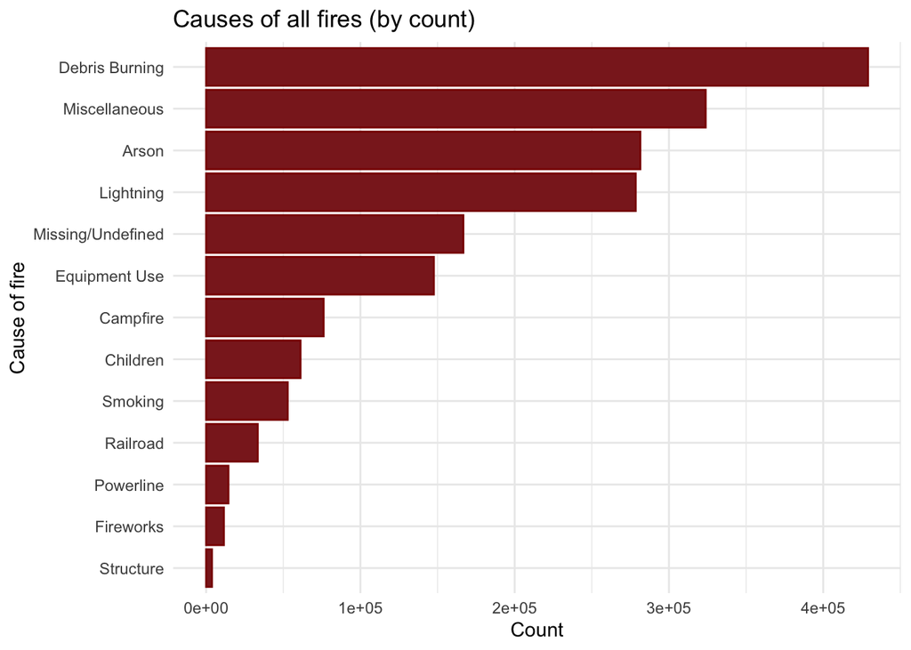

```r
# Show the causes of fire with counts in descending order
ggplot(dbGetQuery(fires, "
           SELECT
           STAT_CAUSE_DESCR,
           count(*) as [count]
           FROM Fires
           GROUP BY STAT_CAUSE_DESCR
           ORDER BY count DESC;"),aes(y=count,x=reorder(STAT_CAUSE_DESCR,count)))+
  geom_bar(stat="identity",fill="brown4", color="darkred")+coord_flip()+
  xlab("Cause of fire")+ylab("Count")+ggtitle("Causes of all fires (by count)")+
  theme_minimal()
```

Lets simplify the causes listed above into three more palatable categories. Natural fires (N) are those caused by lightning. Unknown fires (UK) are the miscellaneous fires or the missing/undefined fires. Man-made fires (M) are all of the other fire categories in our dataset.

```r
#sql query that separates our STAT_CAUSE_DESCR data into the three groups
# outlined above. This column is names CAUSE_GROUP and is what our df is grouped
# on. We then sum the count of each of these categories with the
# column count and the acres burned by each category with total_areas
fires_by_cause<-dbGetQuery(fires, "
           SELECT
           CASE
           WHEN STAT_CAUSE_DESCR == 'Lightning' THEN 'N'
           WHEN TRIM(STAT_CAUSE_DESCR) == 'Miscellaneous' OR
           STAT_CAUSE_DESCR == 'Missing/Undefined' THEN 'UK'
           ELSE 'M'
           END as 'CAUSE_GROUP',
           count(*) as [count],
           ROUND(SUM(FIRE_SIZE), 0) as total_area
           FROM Fires
           GROUP BY CAUSE_GROUP
           ")
#peek at results
fires_by_cause
```

| CAUSE_GROUP | count | total_area |
| --- | --- | --- |
| M | 1111469 | 29953119 |
| N | 278468 | 87033501 |
| UK | 490528 | 23145930 |

Now with one SQL call the differences between these categories both in raw counts and the area burned is clear. Lets represent these differences in a count plot

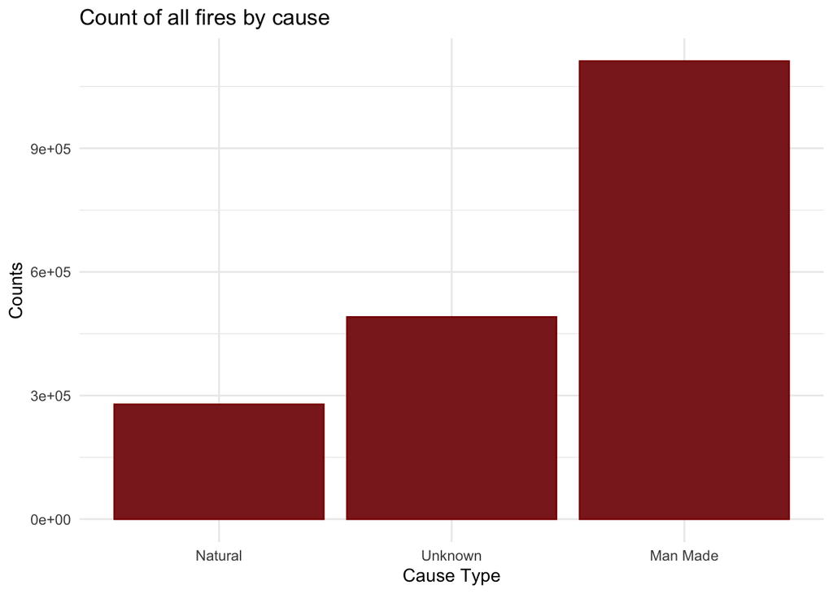

```r
ggplot(fires_by_cause,aes(y=count,x=reorder(CAUSE_GROUP,count)))+
  geom_bar(stat="identity",fill="brown4",color="darkred")+
  theme_minimal()+scale_x_discrete(labels=c("Natural", "Unknown",
  "Man Made"))+labs(x="Cause Type",y="Counts",title=
                      "Count of all fires by cause")
```

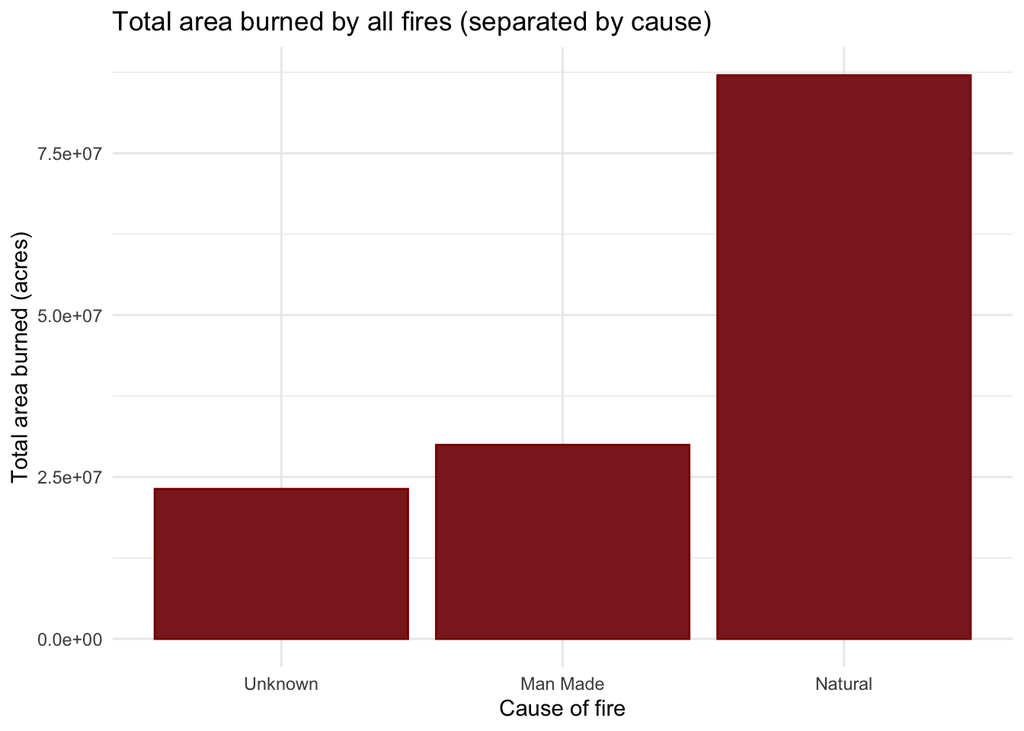

```r
ggplot(fires_by_cause,aes(y=total_area,x=reorder(CAUSE_GROUP,total_area)))+
  geom_bar(stat="identity",fill="brown4", color="darkred")+
  theme_minimal()+scale_x_discrete(labels=
  c("Unknown", "Man Made","Natural"))+labs(x="Cause of fire",y="Total area burned (acres)",title="Total area burned by all fires (separated by cause)")
```

Even though the natural fires have the lowest count they have burned the most acreage. Perhaps this is because these natural fires tend to be further from population centers so they take longer to be noticed?

Map based analysis

Now we will examine every fire occurrence on the map of the United States to see if any trends are visible.

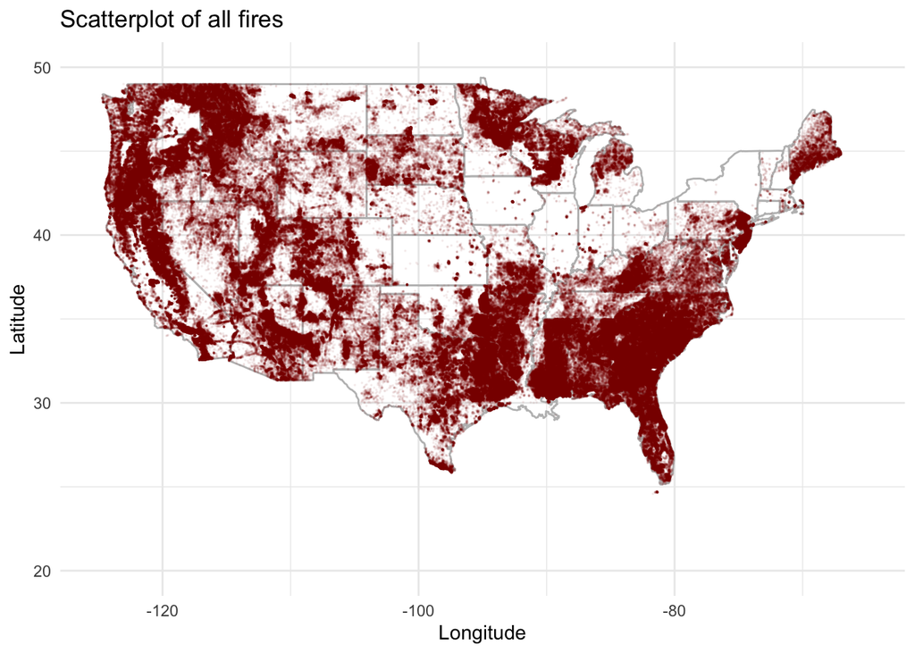

```r
#only showing the first 900000 fires to save memory. This is still a large
#enough sample to show why a scatter plot is a poor representation for this data
scatter_map(dbGetQuery(fires, "
SELECT
LATITUDE,
LONGITUDE
FROM fires")[1:900000,],"LONGITUDE","LATITUDE","Scatterplot of all fires")
```

Due to inconsistencies with the map of Alaska in the mapping package I have been utilizing for the lower 48 states and Hawaii, I have chosen to use a map from a different package. This changes our kernel density code from the function kernel_density_map. Alaska still is using the same kernel density formula under the hood so there shouldn’t be inconsistencies in our results.

```r
#Alaska map
ak_poly<-ggplot(data=dbGetQuery(fires, "
           SELECT
           LATITUDE, LONGITUDE
           FROM fires
           WHERE STATE in ('AK')
           "),aes(y=LATITUDE, x=LONGITUDE))+
  geom_sf(data=us_ak$geometry,inherit.aes = FALSE,color="black",fill="black")+
  stat_density2d(aes(fill = ..level..), alpha = .5,geom = "polygon")+
  scale_fill_viridis_c(alpha=0.3,begin=.55,option="plasma")+
  xlim(-180,-130)+ylim(51,71)+theme_void()+theme(legend.position = 'none')
```

Lets calculate our kernel density for Hawaii and the lower 48 states, which are located in different maps.

```r
#Hawaii map
hi<-kernel_density_map(dbGetQuery(fires, "
           SELECT
           FIRE_YEAR, LATITUDE, LONGITUDE, FIRE_SIZE
           FROM fires
           WHERE STATE in ('HI')
           "),hawaii, "",TRUE)
#lower 48 map
l48<-kernel_density_map(causes,map_data("state"),"Kernel Density of all Fires",FALSE)
```

Now we will display all three of our maps with the patchwork library.

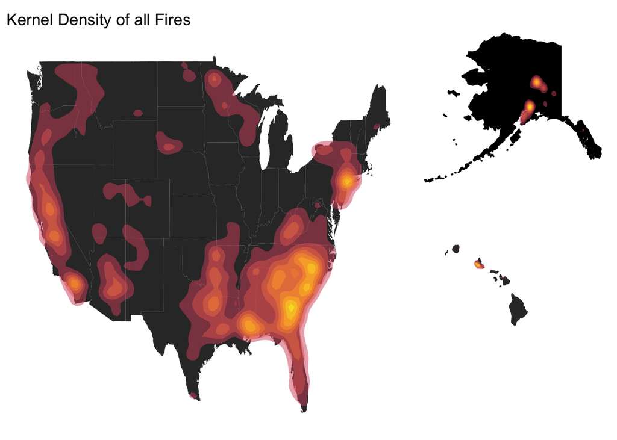

```r
#place Alaska above Hawaii in one pane
lb<-(ak_poly+hi)+plot_layout(nrow=2)

#used to control figure sizing A=lower 48, B= alaska and hawaii figure
layout<- "
AAB
"
#put the lower 48 states on the left and the lb pane on the right
(l48/lb)+plot_layout(design = layout)
```

Fires appear to be densest in the south, with smaller clusters around California and New York. In Alaska the fires are centered around Alaska’s two largest urban centers: Anchorage and Fairbanks In Hawaii the fires are centered on Oahu. Now lets see if fires follow different trends causally.

```r
#same sql query as fire_by_cause except for the final step: grouping the fires
#by their cause
comb_causes<-dbGetQuery(fires, "
           SELECT
           CASE
           WHEN STAT_CAUSE_DESCR == 'Lightning' THEN 'N'
           WHEN TRIM(STAT_CAUSE_DESCR) == 'Miscellaneous' OR
           STAT_CAUSE_DESCR == 'Missing/Undefined' THEN 'UK'
           ELSE 'M'
           END as 'CAUSE_GROUP',
           FIRE_SIZE,
           LATITUDE,
           LONGITUDE,
           STATE
           FROM Fires
           ")

#unknown fires are at c[[3]] but we wont examine those here
c<-split(comb_causes, comb_causes$CAUSE_GROUP)
man<-drop_na(c[[1]])
natural<-drop_na(c[[2]])
```

Now that we have separated out fires by cause, lets see what these density maps elucidate. We will first examine the fires with natural causes (i.e. lightning strikes that led to a subsequent fire).

```r
#nothing changes about our lower 48 call, except the dataframe we are passing in
natural_48<-kernel_density_map(natural,map_data("state"), "Kernel Density of natural fires")
```

```r
#for Hawaii and Alaska we will pull from this dataframe instead of making a SQL
#call for the data.
HI_natural<-natural[natural$STATE=="HI",]
AK_natural<-natural[natural$STATE=="AK",]

ak_poly_natural<-ggplot(AK_natural,aes(y=LATITUDE, x=LONGITUDE))+
  geom_sf(data=us_ak$geometry,inherit.aes = FALSE,color="black",fill="black")+
  stat_density2d(aes(fill = ..level..), alpha = .5,geom = "polygon")+
  scale_fill_viridis_c(alpha=0.3,begin=.55,option="plasma")+
  xlim(-180,-130)+ylim(51,71)+theme_void()+theme(legend.position = 'none')

hi_poly_natural<-kernel_density_map(HI_natural,hawaii, "",TRUE)
```

Now we will display our three maps on one Rnotebook pane

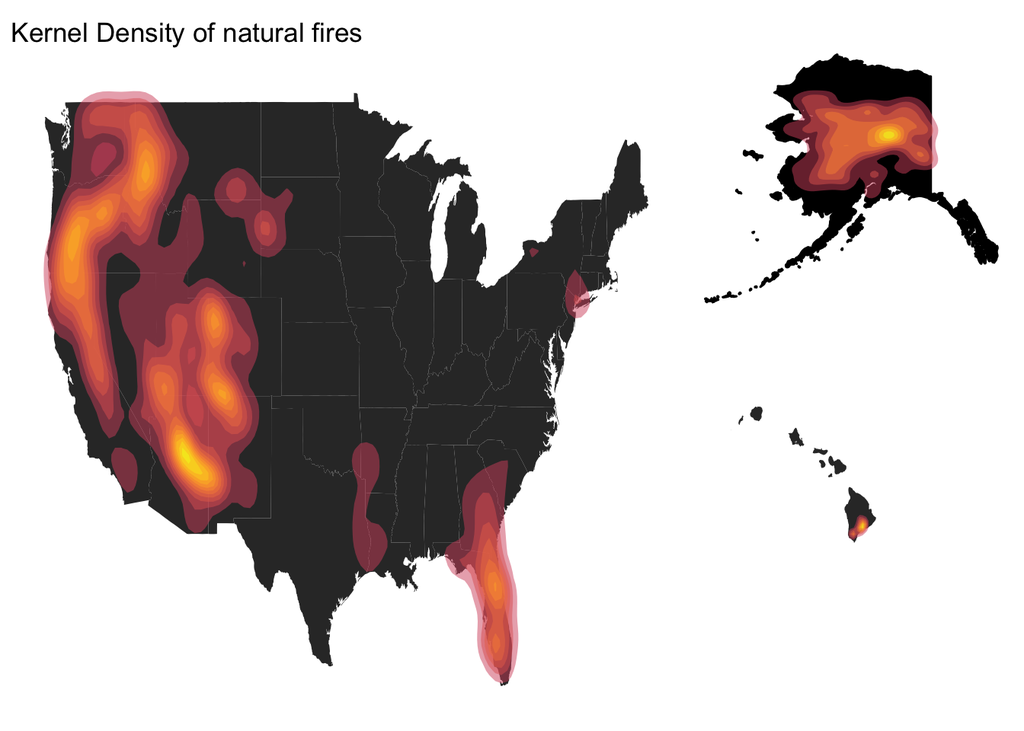

```r
lb<-(ak_poly_natural+hi_poly_natural)+plot_layout(nrow=2)
layout<- "
AAB
"
(natural_48/lb)+plot_layout(design = layout)
```

When looking at natural fires, their density is dramatically shifted west. Only the natural fires in Florida are notable in the south. In Alaska, the density of the fires have shifted from Alaska’s urban centers (Anchorage and Fairbanks) to the center of the middle of the state, including Fairbanks. In Hawaii the fires are centered on the big island around two national parks encompassing the bottom of the big island.

Now we will examine the density maps of fires caused by humans.

```r
#lower 48 map
man_48<-kernel_density_map(man,map_data("state"),"Density of man-made fires")
```

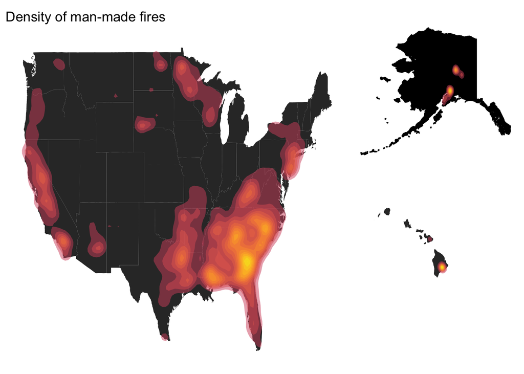

```r
#Hawaii and Alaska maps
HI_man<-man[man$STATE=="HI",]
AK_man<-man[man$STATE=="AK",]

ak_poly_man<-ggplot(AK_man,aes(y=LATITUDE, x=LONGITUDE))+
  geom_sf(data=us_ak$geometry,inherit.aes = FALSE,color="black",fill="black")+
  stat_density2d(aes(fill = ..level..), alpha = .5,geom = "polygon")+
  scale_fill_viridis_c(alpha=0.3,begin=.55,option="plasma")+
  xlim(-180,-130)+ylim(51,71)+theme_void()+theme(legend.position = 'none')

hi_poly_man<-kernel_density_map(HI_man,hawaii, "",TRUE)
lb<-(ak_poly_man+hi_poly_man)+plot_layout(nrow=2)
layout<- "
AAB
"
(man_48/lb)+plot_layout(design = layout)
```

The above density maps count each fire equally, no matter the size. To get rid of this bias, lets examine the acres burned by state.

```r
state_causes<-dbGetQuery(fires, "
           SELECT
           STATE AS state,
           ROUND(SUM(FIRE_SIZE), 0) as total_area
           FROM Fires
           Where STATE not in ('PR','DC')
           GROUP BY STATE
           ")

head(state_causes)
```

|  | state | total_area |
| --- | --- | --- |
| 1 | AK | 32233094 |
| 2 | AL | 920545 |
| 3 | AR | 508912 |
| 4 | AZ | 5576681 |
| 5 | CA | 12745859 |
| 6 | CO | 1842309 |

### Examination of fires by state

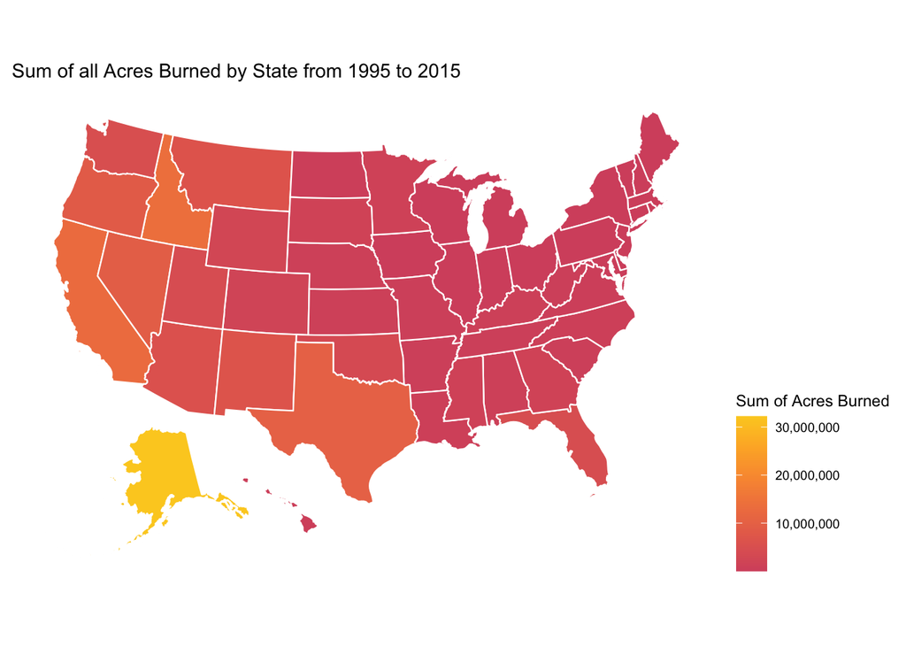

```r
plot_usmap(data = state_causes,values="total_area",color="white") +
  scale_fill_viridis_c(alpha=1,begin=.55, end=0.9,option="plasma",
                       name = "Sum of Acres Burned", label = scales::comma) +
  labs(title = "Sum of all Acres Burned by State from 1995 to 2015") +
  theme(legend.position = "right")
```

At this scale acres burned is clearly connected to the size of the state with larger states having more total acres burned by fires. This makes sense because they have a larger burn potential then the smaller states.Lets see if this trend persists when we account for the area of the states.

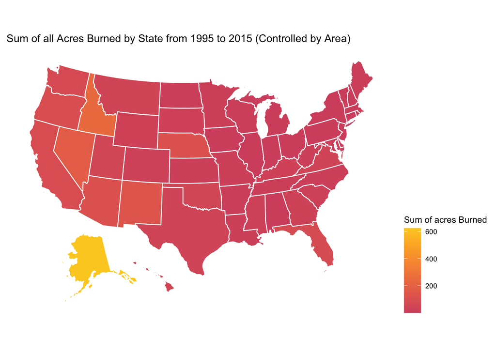

```r
#get area of states from built in R data
data("state")
df<-data.frame("area_km2"=state.area)
#see which state has had the most burn relative to their size
#(area burned/state size)
state_causes$burned_by_area<-state_causes$total_area/df$area_km2
plot_usmap(data = state_causes,values="burned_by_area",color="white")+
  scale_fill_viridis_c(alpha=1,begin=.55, end=0.9,option="plasma",
                       name = "Sum of acres Burned", label = scales::comma)+
  labs(title = "Sum of all Acres Burned by State from 1995 to 2015 (Controlled by Area)")+
  theme(legend.position = "right")
```

Examanation of fires by year

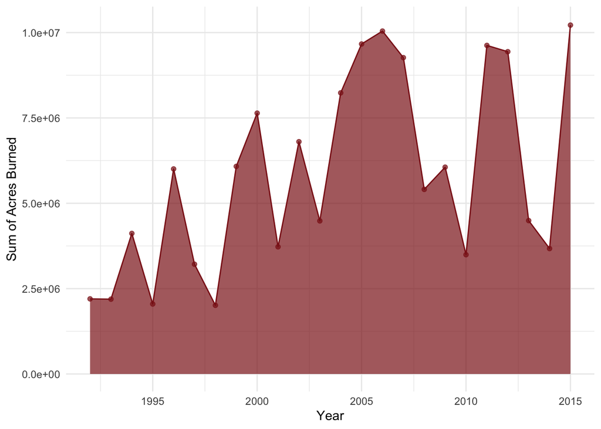

```r
ggplot(data=dbGetQuery(fires, "
           SELECT
           FIRE_YEAR as year,
           ROUND(SUM(FIRE_SIZE), 0) as total_area
           FROM Fires
           GROUP BY FIRE_YEAR
           "), aes(x=year, y=total_area, group=1)) +
  geom_area(alpha=0.7,fill="firebrick4")+
  geom_line(color="firebrick4")+
  geom_point(alpha=0.7,colour="firebrick4")+
  ylim(0,10250000)+theme_minimal()+xlab("Year")+ylab("Sum of Acres Burned")
```

Examining this plot, we can see the smallest fire year was in 1998 and the largest fire year was in 2015. 8,207,166, or 5x more acres burned in 2015 than 1998. Is there a functional reason for this difference (e.g., more man-made fires, more fires in an ill-equipped area) or did these two years follow the classical trends just on differing scales?

Start of unfinished work: First we will query our dataset for fires from 2015 and 1998

```r
year_2015<-dbGetQuery(fires, "
           SELECT
           LATITUDE, LONGITUDE, FIRE_SIZE
           FROM fires
           WHERE FIRE_YEAR in (2015)
           ")

year_1998<-dbGetQuery(fires, "
           SELECT
           LATITUDE, LONGITUDE, FIRE_SIZE
           FROM fires
           WHERE FIRE_YEAR in (1998)
           ")
```

First we will calculate the 1998 data

```r
#hawaii
hi_98<-kernel_density_map(year_1998,hawaii, "",TRUE)
```

```r
#alaska
ak_98<-ggplot(year_1998,aes(y=LATITUDE, x=LONGITUDE))+
  geom_sf(data=us_ak$geometry,inherit.aes = FALSE,color="black",fill="black")+
  stat_density2d(aes(fill = ..level..), alpha = .5,geom = "polygon")+
  scale_fill_viridis_c(alpha=0.3,begin=.55,option="plasma")+
  xlim(-180,-130)+ylim(51,71)+theme_void()+theme(legend.position = 'none')
#lower 48
l48_98<-kernel_density_map(year_1998,map_data("state"),"Density of fires in 1998")

panel_1998<-arrange_states(ak_98,hi_98,l48_98)
```

Then the 2015 data

```r
#hawaii
hi_15<-kernel_density_map(year_2015,hawaii, "",TRUE)
```

```r
#alaska
ak_15<-ggplot(year_2015,aes(y=LATITUDE, x=LONGITUDE))+
  geom_sf(data=us_ak$geometry,inherit.aes = FALSE,color="black",fill="black")+
  stat_density2d(aes(fill = ..level..), alpha = .5,geom = "polygon")+
  scale_fill_viridis_c(alpha=0.3,begin=.55,option="plasma")+
  xlim(-180,-130)+ylim(51,71)+theme_void()+theme(legend.position = 'none')
#lower 48
l48_15<-kernel_density_map(year_2015,map_data("state"),"Density of fires in 2015")
#arrange
panel_2015<-arrange_states(ak_15,hi_15,l48_15)
```

Now we will present the graphs on top of one another to allow for direct comparison

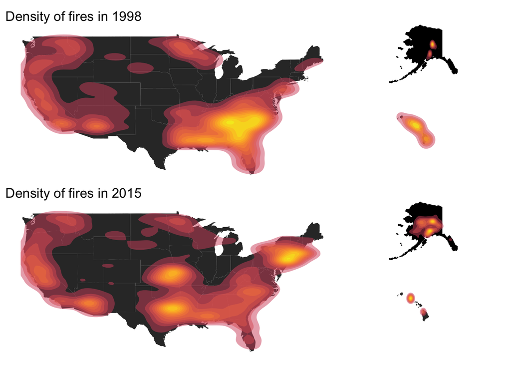

```r
(panel_1998|panel_2015)+plot_layout(nrow=2)
```

**Lower 48 states:**

1998: The lower 48 states have their densest area in the south and largely match the shape of the map of all years of fires.

2015: The fires have more density centers and cover a larger portion of the map, especially in the Midwest and New England.

**Alaska:**

1998: The fires are centered around the urban centers of Alaska, just as they are in the map of all fire years.

2015: The fires are just as heavily centered in the urban centers, but have also spread to much of the area surrounding them in the middle of the state.

**Hawaii:**

1998: The fires seem to encompass the entire state. This either could be due to an unseemly amount of fires in Hawaii that year, or that there was not enough data for the density map to find its center. Either way Hawaii is too small to significantly effect the fire trends of the whole country.

2015: The fires are centered on the same island as the map with all of the fire years, with additional fires on the big island.